# 电子游戏销售分析

```
姓名：孙天艺
学号：3220190867
```

## 一、数据概览与预处理

### 1.1 数据集结构

```
Rank：总销售量的排名
Name：游戏名称
Platform：游戏发行平台
Year：游戏发行时间
Genre：游戏类别
Publisher：发行商
NA_Sales：北美的销售量，单位为百万
EU_Sales：欧洲的销售量，单位为百万
JP_Sales：日本的销售量，单位为百万
Other_Sales：其它地区的销售量，单位为百万
Global_Sales：全球的销售量
```

### 1.2 读取数据

```python
import pandas as pd

filename = 'vgsales.csv'
vgs = pd.read_csv(filename,index_col='Rank')

vgs.head(5)    #打印前5行
```

| Rank | Name | Platform | Year | Genre | Publisher | NA_Sales | EU_Sales | JP_Sales | Other_Sales | Global_Sales |
| --- | --- | --- | --- | --- | --- | --- | --- | --- | --- | --- |
| 1 | Wii Sports | Wii | 2006.0 | Sports | Nintendo | 41.49 | 29.02 | 3.77 | 8.46 | 82.74 |
| 2 | Super Mario Bros. | NES | 1985.0 | Platform | Nintendo | 29.08 | 3.58 | 6.81 | 0.77 | 40.24 |
| 3 | Mario Kart Wii | Wii | 2008.0 | Racing | Nintendo | 15.85 | 12.88 | 3.79 | 3.31 | 35.82 |
| 4 | Wii Sports Resort | Wii | 2009.0 | Sports | Nintendo | 15.75 | 11.01 | 3.28 | 2.96 | 33.00 |
| 5 | Pokemon Red/Pokemon Blue | GB | 1996.0 | Role-Playing | Nintendo | 11.27 | 8.89 | 10.22 | 1.00 | 31.37 |

### 1.3 缺失值处理

```python
vgs.isnull().sum()    #统计缺失值
```

```
Name              0
Platform          0
Year            271
Genre             0
Publisher        58
NA_Sales          0
EU_Sales          0
JP_Sales          0
Other_Sales       0
Global_Sales      0
dtype: int64
```

可以发现：发行时间与发行商两列存在缺失值  
由于相对总体，缺失的值规模比较小，可以采取直接删除

```python
vgs = vgs.dropna()    #丢弃含有缺失值的行
vgs.isnull().sum()    #重新统计缺失值
```

```
Name            0
Platform        0
Year            0
Genre           0
Publisher       0
NA_Sales        0
EU_Sales        0
JP_Sales        0
Other_Sales     0
Global_Sales    0
dtype: int64
```

## 二、全球市场分析

```
——最受欢迎的游戏类型、平台、发行商
```

### 2.1 最受欢迎的游戏类型

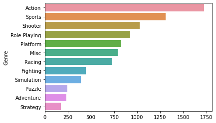

```python
import matplotlib.pyplot as plt
import seaborn as sns
%matplotlib inline

# 获取游戏类型的排序
Genre_data = vgs.groupby(['Genre']).sum().loc[:, 'Global_Sales'].sort_values(ascending = False)

# 进行画图
sns.barplot(y = Genre_data.index, x = Genre_data.values, orient='h')
plt.ylabel = "Genre"
plt.xlabel = "Global_Sales"
plt.show()
```

从图中可以看到：动作类和运动类游戏最受欢迎

### 2.2 最受欢迎的游戏平台

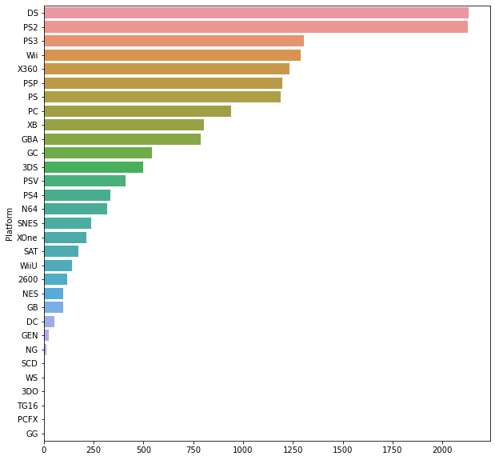

```python
# 获取游戏平台的排序
Platform_data = vgs.groupby(['Platform']).count().loc[:,"Name"].sort_values(ascending = False)

# 进行画图
plt.figure(figsize=(10,10))
sns.barplot(y = Platform_data.index, x = Platform_data.values, orient='h')
plt.ylabel = "Platform"
plt.xlabel = "The amount of games"
plt.show()
```

从图中可以看到：  
DS和PS2是最受欢迎的发行平台  
3DO、TG16、PCFX、GG等，已经在没落

### 2.3 最受欢迎的游戏发行商

```python
# 获取游戏发行商的排序
Publisher_data = vgs.groupby(['Publisher']).sum().loc[:,"Global_Sales"].sort_values(ascending = False)
```

```python
print(len(Publisher_data))
```

```
576
```

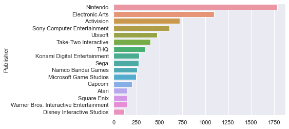

```python
# 只保留Publisher_data.values>50的数据
Publisher_data = Publisher_data[Publisher_data.values > 100]

# 进行画图
sns.set(font_scale=1)
plt.ylabel = "Publisher"
plt.xlabel = "Global_Sales"
sns.barplot(y = Publisher_data.index, x = Publisher_data.values, orient='h')
plt.show()
```

从图中可以看到：  
Nintendo最受欢迎的发行商  
其销量远远超出了第二名Electronic Arts

## 三、地区偏好分析

```
——不同地区的各类型、各发行商销售额占比
```

### 3.1 各地区的不同类型游戏销售额占比

```python
# 加入以下两行代码，绘图中可显示中文
plt.rcParams['font.sans-serif'] = [u'SimHei']
plt.rcParams['axes.unicode_minus'] = False
```

```python
# 获取各地不同类别游戏的销售额排名
Genre_NA = vgs.groupby(['Genre']).sum().loc[:, 'NA_Sales'].sort_values(ascending = False)
Genre_EU = vgs.groupby(['Genre']).sum().loc[:, 'EU_Sales'].sort_values(ascending = False)
Genre_JP = vgs.groupby(['Genre']).sum().loc[:, 'JP_Sales'].sort_values(ascending = False)
Genre_Other = vgs.groupby(['Genre']).sum().loc[:, 'Other_Sales'].sort_values(ascending = False)
```

```python
# 获取游戏类别
Genre_name = Genre_NA._stat_axis.values.tolist()
```

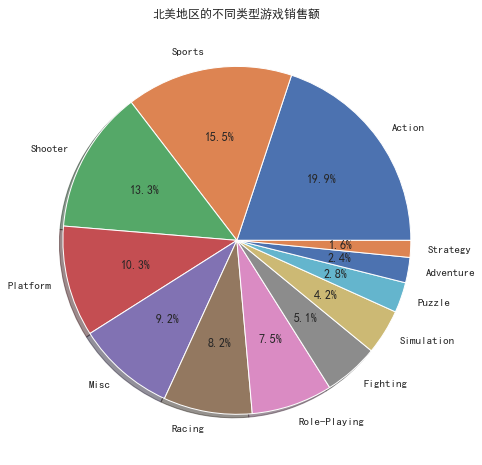

```python
plt.figure(figsize = (8,8))
plt.pie(x = Genre_NA,labels = Genre_name,autopct = "%0.1f%%",shadow = True)
plt.title("北美地区的不同类型游戏销售额")
plt.show()
```

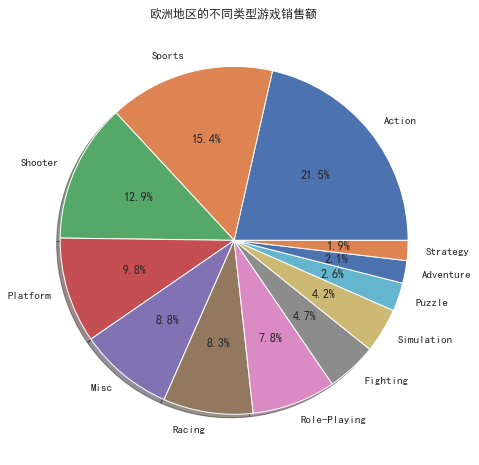

```python
plt.figure(figsize = (8,8))
plt.pie(x = Genre_EU,labels = Genre_name,autopct = "%0.1f%%",shadow = True)
plt.title("欧洲地区的不同类型游戏销售额")
plt.show()
```

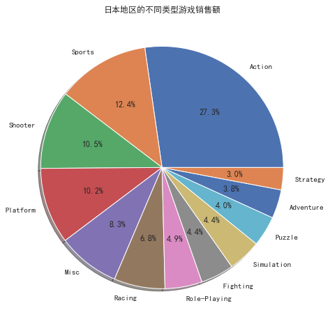

```python
plt.figure(figsize = (8,8))
plt.pie(x = Genre_JP,labels = Genre_name,autopct = "%0.1f%%",shadow = True)
plt.title("日本地区的不同类型游戏销售额")
plt.show()
```

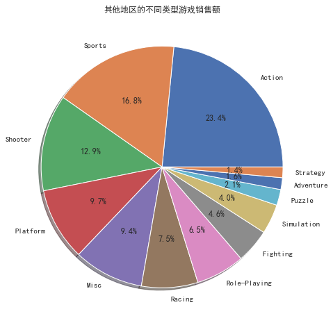

```python
plt.figure(figsize = (8,8))
plt.pie(x = Genre_Other,labels = Genre_name,autopct = "%0.1f%%",shadow = True)
plt.title("其他地区的不同类型游戏销售额")
plt.show()
```

### 3.2 各地区的不同游戏发行商销售额占比

```python
# 获取各地不同游戏发行商的销售额排名
Publisher_NA = vgs.groupby(['Publisher']).sum().loc[:, 'NA_Sales'].sort_values(ascending = False)
Publisher_EU = vgs.groupby(['Publisher']).sum().loc[:, 'EU_Sales'].sort_values(ascending = False)
Publisher_JP = vgs.groupby(['Publisher']).sum().loc[:, 'JP_Sales'].sort_values(ascending = False)
Publisher_Other = vgs.groupby(['Publisher']).sum().loc[:, 'Other_Sales'].sort_values(ascending = False)
```

```python
# 由于游戏发行商的数量太多，无法在一张图片中显示出
# 仍只考虑Publisher_data.values>50，即销售量超过5000万份游戏发行商
Publisher_NA = Publisher_NA[Publisher_NA.values > 50]
Publisher_EU = Publisher_EU[Publisher_EU.values > 50]
Publisher_JP = Publisher_JP[Publisher_JP.values > 50]
Publisher_Other = Publisher_Other[Publisher_Other.values > 50]
```

```python
# 获取游戏发行商
Publisher_name_NA = Publisher_NA._stat_axis.values.tolist()
Publisher_name_EU = Publisher_EU._stat_axis.values.tolist()
Publisher_name_JP = Publisher_JP._stat_axis.values.tolist()
Publisher_name_Other = Publisher_Other._stat_axis.values.tolist()
```

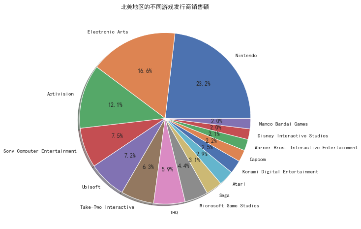

```python
plt.figure(figsize = (8,8))
plt.pie(x = Publisher_NA,labels = Publisher_name_NA,autopct = "%0.1f%%",shadow = True)
plt.title("北美地区的不同游戏发行商销售额")
plt.show()
```

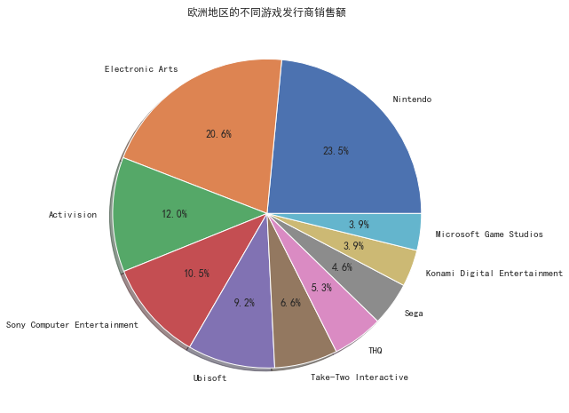

```python
plt.figure(figsize = (8,8))
plt.pie(x = Publisher_EU,labels = Publisher_name_EU,autopct = "%0.1f%%",shadow = True)
plt.title("欧洲地区的不同游戏发行商销售额")
plt.show()
```

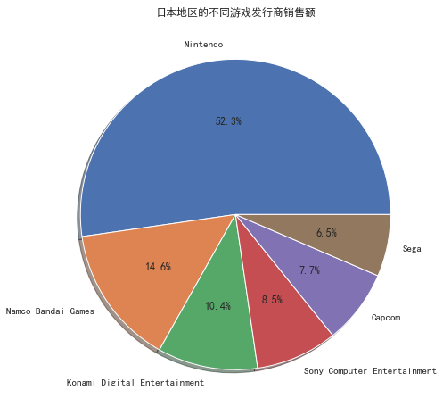

```python
plt.figure(figsize = (8,8))
plt.pie(x = Publisher_JP,labels = Publisher_name_JP,autopct = "%0.1f%%",shadow = True)
plt.title("日本地区的不同游戏发行商销售额")
plt.show()
```

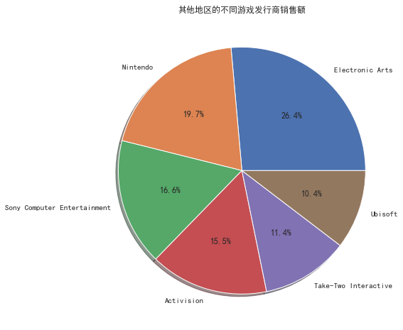

```python
plt.figure(figsize = (8,8))
plt.pie(x = Publisher_Other,labels = Publisher_name_Other,autopct = "%0.1f%%",shadow = True)
plt.title("其他地区的不同游戏发行商销售额")
plt.show()
```

## 四、销售额预测

数据集中每年的销售额如下：

```python
# 获取销售额数据
sales = vgs[['Year', 'Global_Sales']].dropna()
sales = sales.groupby(by = ['Year']).sum().reset_index()
sales
```

|  | Year | Global_Sales |
| --- | --- | --- |
| 0 | 1980.0 | 11.38 |
| 1 | 1981.0 | 35.77 |
| 2 | 1982.0 | 28.86 |
| 3 | 1983.0 | 16.79 |
| 4 | 1984.0 | 50.36 |
| 5 | 1985.0 | 53.94 |
| 6 | 1986.0 | 37.07 |
| 7 | 1987.0 | 21.74 |
| 8 | 1988.0 | 47.22 |
| 9 | 1989.0 | 73.45 |
| 10 | 1990.0 | 49.39 |
| 11 | 1991.0 | 32.23 |
| 12 | 1992.0 | 76.16 |
| 13 | 1993.0 | 45.98 |
| 14 | 1994.0 | 79.17 |
| 15 | 1995.0 | 88.11 |
| 16 | 1996.0 | 199.15 |
| 17 | 1997.0 | 200.98 |
| 18 | 1998.0 | 256.47 |
| 19 | 1999.0 | 251.27 |
| 20 | 2000.0 | 201.56 |
| 21 | 2001.0 | 331.47 |
| 22 | 2002.0 | 395.52 |
| 23 | 2003.0 | 357.85 |
| 24 | 2004.0 | 414.01 |
| 25 | 2005.0 | 458.51 |
| 26 | 2006.0 | 521.04 |
| 27 | 2007.0 | 609.92 |
| 28 | 2008.0 | 678.90 |
| 29 | 2009.0 | 667.30 |
| 30 | 2010.0 | 600.29 |
| 31 | 2011.0 | 515.80 |
| 32 | 2012.0 | 363.49 |
| 33 | 2013.0 | 368.11 |
| 34 | 2014.0 | 337.03 |
| 35 | 2015.0 | 264.44 |
| 36 | 2016.0 | 70.90 |
| 37 | 2017.0 | 0.05 |
| 38 | 2020.0 | 0.29 |

从图中可以看到：  
2016、2017 和 2020 这三年的数据较为异常，  
故在后续处理中将其去除，并纳入预测范围

```python
sales.drop(sales.tail(3).index, inplace = True)
```

使用线性回归预测：

```python
# 划分训练集和测试集
from sklearn.model_selection import train_test_split
import numpy as np
x_train, x_test, y_train, y_test = train_test_split(np.array(sales['Year']), np.array(sales['Global_Sales']))
```

```python
x_train = [[x] for x in x_train]
x_test = [[x] for x in x_test]
y_train = [[y] for y in y_train]
y_test = [[y] for y in y_test]
```

```python
# 线性回归模型
from sklearn.linear_model import LinearRegression
model = LinearRegression()
model.fit(x_train, y_train)
```

```
LinearRegression(copy_X=True, fit_intercept=True, n_jobs=None, normalize=False)
```

```python
y_predict = model.predict(x_test)
test_accuracy = model.score(x_test, y_test)

print(test_accuracy)
```

```
0.7489482692038923
```

```python
x_full = [[x] for x in list(sales['Year'])]
y_full = [[y] for y in list(sales['Global_Sales'])]
model = LinearRegression()
model.fit(x_full, y_full)
x_predict = [2017, 2018, 2019, 2020, 2021]
x_predict = [[x] for x in x_predict]
y_predict = model.predict(x_predict)
```

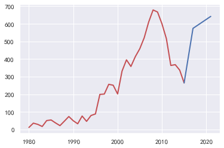

```python
y_predict_for_plot = []
for i in range(len(x_full) - 1):
    y_predict_for_plot.append([float('NaN')])
y_predict_for_plot.append(y_full[-1])
for y in y_predict:
    y_predict_for_plot.append(list(y))
t = np.arange(len(x_full))
plt.figure()
plt.plot(x_full, y_full, 'r-', linewidth = 2, label = '真实值')
plt.plot(x_full + x_predict, y_predict_for_plot, 'b-', linewidth = 2, label = '预测值')
```

## 五、总结

[output not shown]